# Guía 14 Análisis de varianza y posteriores

Diplomado Análisis de datos con R e investigación reproducible para Biociencias.

Dr. José A. Gallardo y Dra. María Angélica Rueda.

Pontificia Universidad Católica de Valparaíso  
jose.gallardo@pucv.cl

15 October 2022

#### **Introducción**

**Análisis de Varianza**

Es una herramienta de inferencia estadística muy usada en el campo de investigación científico-técnica de las ciencias biológicas y en particular en la acuicultura. El ANOVA es un método estadístico cuya finalidad es probar hipótesis referidas a los parámetros de posición de dos o más poblaciones en estudio.

**Comparación a posteriori**

Existen diversas pruebas a posteriori para analizar el porque se rechaza la hipotesis nula que se está considerando en nuestro estudio; es decir, si rechazamos la hipótesis nula del ANOVA, la pregunta que podríamos hacernos es la siguiente **¿cuál o cuáles de las medias poblacionales en estudio son las diferentes?** Existen diversas pruebas a posteriori para analizar está problemática; no obstante, en esta guía usaremos la *prueba de Tukey*.

#### **Objetivos de aprendizaje**

Los objetivos de aprendizaje de esta guía son:

**1**. - Elaborar hipótesis estadísticas.

**2**. - Realizar análisis de varianza y comparaciones a posteriori.

**3**. - Elaborar un reporte dinámico en formato html con **[Rmarkdown](https://rmarkdown.rstudio.com/)**.

#### **Comandos**

A continuación, se presentan algunos comandos que deberá usar para resolver los ejercicios de esta guía.

**1.-** **lm():** se utiliza para ajustar modelos lineales. También, se puede utilizar para realizar regresiones, análisis de varianza de un factor o dos factores de clasificación (se puede considerar interacción entre los factores) y análisis de covarianza (aunque aov puede proporcionar una interfaz más conveniente para el ANOVA).

**2.-** **aov():** se usa para ajustar un modelo de análisis de varianza.

**3.-** **anova():** se usa para hacer un ANOVA sobre el objeto obtenido al ajustar un modelo con las funciones lm() o aov().

**4.-** **TukeyHSD():** se usa para hacer la prueba a posteriori de Tukey.

**5.-** **grid.arrange():** se usa para hacer gráficas multiples en un panel.

**Nota:** La prueba Tukey trabaja sobre un objeto *aov*, no sobre un objeto lm.

### **Ejercicio 1.** **Elaborar archivo Rmarkdown**

Usando lo aprendido en la unidad 1 del curso elabore y configure un archivo o file con extensión **.Rmd** y configúrelo para exportar el resultado como un documento dinámico **html**.

Complete la información de metadatos con: Título: Reporte Anova y posteriores. Nombre del autor: Su nombre.

Luego guarde inmediatamente su *script* como **script_anova_nombre_apellido.Rmd**.

### **Ejercicio 2.** **Configuración del reporte**

En el primer bloque de códigos o **chunk** configure los comandos de la siguiente manera *knitr::opts_chunk$set(echo = TRUE)* y cargue los paquetes **ggplot2**, **readxl**, **pander**, **dplyr**, **knitr** y **gridExtra**.

```r
knitr::opts_chunk$set(echo = TRUE)

# Paquete para gráficas avanzadas
library(ggplot2)

# Paquete para importar datos
library(readxl)

# Paquete para mostrar en formato tabla los resultados de un objeto
library(pander)

# Paquete para usar funciones de tidyverse
library(dplyr)

# Paquetes para hacer tablas
library(knitr)

library(gridExtra)

# Paquete con bases de datos agrícolas
library(agriTutorial)
```

### **Ejercicio 3.** **Anova a un criterio de clasificación con dos niveles**

La base de datos **Tilapia_nilotica_data.xlsx** contiene información del peso final **(Final_Weight_g)** y cepa **(Cepa)** de 200 tilapias. Los investigadores desean evaluar si el crecimiento medido como peso final es diferente entre dos Cepas comerciales de *Oreochromis niloticus* (**Spring** *vs* **cepa B**). Ambas cepas se evaluaron durante 157 días (34 días en vivero y 123 en engorde) en la finca Los Pozos, El Rosario, Sinaloa, México. La cantidad de observaciones del set de datos **Tilapia_nilotica_data.xlsx** es igual a 200, 100 observaciones para cada cepa. Datos simulados a partir de información estadística del siguiente artículo [Espinosa-Chaurand et al., 2019](https://scielo.conicyt.cl/scielo.php?pid=S0718-560X2019000300440&script=sci_arttext)

**a).** Formule la hipótesis nula y alternativa para este experimento.

```r
#**H~0~**: $$ \mu_{Spring} = \mu_{B}$$

#**H~1~**: $$ \mu_{Spring} \ne \mu_{B}$$
```

**b).** Importe el set de datos **Tilapia_nilotica_data.xlsx** usando la función **read_excel()** del paquete **readxl**, llame al objeto Tilapia_nilotica. Transformar en factor la variable Cepa con la función **as.factor()**. Explore el set de datos usando las funciones **head()**, **str()** y **summary()**.

```r
Tilapia_nilotica <- read_excel("Tilapia_nilotica_data.xlsx")
Tilapia_nilotica$Cepa <- as.factor(Tilapia_nilotica$Cepa)
head(Tilapia_nilotica)
```

```
## # A tibble: 6 × 3
##      ID Cepa   Final_Weight_g
##   <dbl> <fct>           <dbl>
## 1     1 Spring            495
## 2     2 Spring            538
## 3     3 Spring            484
## 4     4 Spring            613
## 5     5 Spring            546
## 6     6 Spring            485
```

```r
str(Tilapia_nilotica)
```

```
## tibble [200 × 3] (S3: tbl_df/tbl/data.frame)
##  $ ID            : num [1:200] 1 2 3 4 5 6 7 8 9 10 ...
##  $ Cepa          : Factor w/ 2 levels "B","Spring": 2 2 2 2 2 2 2 2 2 2 ...
##  $ Final_Weight_g: num [1:200] 495 538 484 613 546 485 554 568 559 512 ...
```

```r
summary(Tilapia_nilotica)
```

```
##        ID             Cepa     Final_Weight_g
##  Min.   :  1.00   B     :100   Min.   :207.0
##  1st Qu.: 50.75   Spring:100   1st Qu.:384.0
##  Median :100.50                Median :494.0
##  Mean   :100.50                Mean   :466.4
##  3rd Qu.:150.25                3rd Qu.:548.2
##  Max.   :200.00                Max.   :656.0
```

**c).** Realice un análisis exploratorio de datos de la variable bajo estudio usando **geom_histogram()** y **geom_boxplot()**. A partir del set de datos de elabore un gráfico de cajas y bigotes para la variable **Final_Weight_g**. Utilice grid.arrange() para colocar ambas gráficas en un panel.

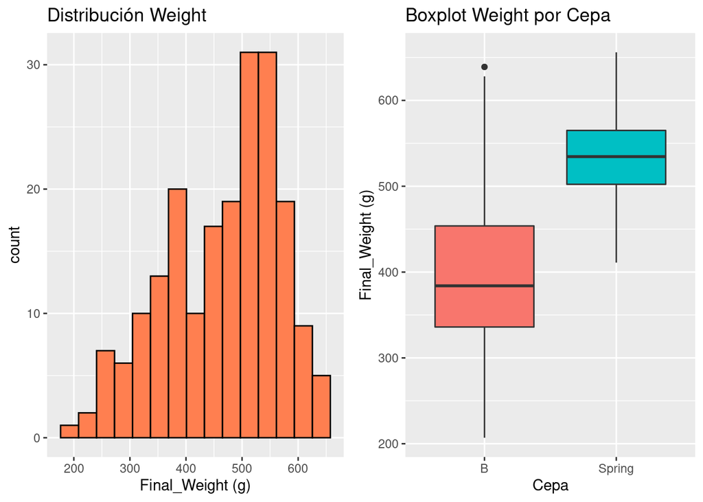

```r
plot1 <- Tilapia_nilotica %>%
          ggplot(aes(x= Final_Weight_g))+
                geom_histogram(color="black", fill="coral", position = "identity", bins = 15)+
                theme(legend.position="none")+
                labs(x="Final_Weight (g)",title="Distribución Weight")


plot2 <- Tilapia_nilotica %>%
          ggplot(aes(x= Cepa,y=Final_Weight_g,fill=Cepa))+
                geom_boxplot()+
                theme(legend.position="none")+
                labs(x="Cepa",y="Final_Weight (g)",title="Boxplot Weight por Cepa")

grid.arrange(plot1, plot2, ncol=2, nrow =1)
```

**d).** Incluya una tabla con los estimadores puntuales de los promedios y las varianzas de la variable Final_Weight_g para cada nivel del factor Cepa, incluya también el N muestral. Use el paquete dplyr y los comandos **group_by()**, **summarise()**.

```r
# Promedio y varianza de la variable Final_Weight_g para la Cepa Spring.

Tabla = Tilapia_nilotica %>% group_by(Cepa) %>%
summarise(N= n(), Promedio = mean(Final_Weight_g),
          Varianza= var(Final_Weight_g))


knitr::kable(Tabla,caption ="Estimadores puntuales de media y varianza de Final_Weight(g) para las cepas Spring y B")
```

Estimadores puntuales de media y varianza de Final_Weight(g) para las cepas Spring y B

| Cepa | N | Promedio | Varianza |
| --- | --- | --- | --- |
| B | 100 | 398.60 | 9616.444 |
| Spring | 100 | 534.26 | 2274.194 |

**e).** Realice el ajuste del siguiente modelo usando la función **lm()**, donde los parámetros son los siguientes: variable respuesta **Final_Weight_g** y como factor de clasificación **Cepa**, como set de datos (data=Tilapia_nilotica). Llame al objeto model1_anova1. Utilice el simbolo ~ para relacionar la variable respuesta con el factor de clasificación. Luego, realice el anova() del objeto model1_anova1.

```r
model1_anova1 <- lm(Final_Weight_g ~ Cepa, data=Tilapia_nilotica)
anova(model1_anova1)
```

```
## Analysis of Variance Table
##
## Response: Final_Weight_g
##            Df  Sum Sq Mean Sq F value    Pr(>F)
## Cepa        1  920182  920182  154.77 < 2.2e-16 ***
## Residuals 198 1177173    5945
## ---
## Signif. codes:  0 '***' 0.001 '**' 0.01 '*' 0.05 '.' 0.1 ' ' 1
```

Use la función pander::pander() para mostrar los resultados del modelo (model1_anova1), coloque en el parámetro caption “ANOVA a una vía de clasificación.”

```r
pander::pander(model1_anova1, caption = "ANOVA a una vía de clasificación.")
```

ANOVA a una vía de clasificación.

|  | Estimate | Std. Error | t value | Pr(>\|t\|) |
| --- | --- | --- | --- | --- |
| **(Intercept)** | 398.6 | 7.711 | 51.7 | 6.341e-117 |
| **CepaSpring** | 135.7 | 10.9 | 12.44 | 1.25e-26 |

**f).** Interprete los resultados.

```r
#El efecto cepa es estadísticamente significativo (p valor menor al nivel de significación del 5%). En consecuencia se rechaza la hipótesis nula. Por lo tanto, existen diferencias entre los pesos finales promedios de las cepa Spring y B.
```

### **Ejercicio 4.** **Anova a un criterio de clasificación con tres niveles y Prueba a Posteriori Tukey**

En este estudio de caso trabajaremos con un set de datos de trucha arcoíris en una estación de cultivo del Ecuador (n=54).

Las variables de estudio se describen a continuación:

| **variable** | **Descripción** | **Tipo de efecto/variable** |
| --- | --- | --- |
| **Probiotico** | Dosis de probiótico fresh plus: 0 g/kg (P0: alimento sin probiotico) , 6 g/kg (P1= 6 gramos de probiotico por kilo de alimento) y 12 g/Kg (P2: 12 gramos de probiotico por kilo de alimento ). | Criterio de clasificación. |
| **Fuente** | Dos fuentes de agua: F1: Agua Natural del río Papallacta - normalmente usada en la crianza de los peces y F2: mezcla de agua natural con agua geotermal | Criterio de clasificación. |
| **Tiempo_Dias** | Cantidad de días en los que se llevó a cabo el experimento | Criterio de clasificación. |
| **indice_condicion_corporal** | Índice de condición corporal. | Continua |

**a).** Formule una hipótesis para evaluar si el índice de condición difiere entre días de cultivo.

```r
#**H~0~**: $$ \mu_{15} = \mu_{30} = \mu_{45}$$

#**H~1~**: Al menos una de las medias del indice corporal es diferente entre los días evaluados.
```

**b).** Importe el set de datos **Trucha.xlsx** usando la función **read_excel()** del paquete **readxl**, llame al objeto Trucha. Transformar en factor las variables Probiotico, Fuente y Tiempo_Dias con la función **as.factor()**. Explore el set de datos usando las funciones **head()**, **str()** y **summary()**.

```
## # A tibble: 6 × 4
##   Probiotico Fuente Tiempo_Dias indice_condicion_corporal
##   <fct>      <fct>  <fct>                           <dbl>
## 1 P1         F1     15                               1.07
## 2 P1         F1     15                               1.02
## 3 P1         F1     15                               1.31
## 4 P2         F1     15                               1.17
## 5 P2         F1     15                               1.19
## 6 P2         F1     15                               1.36
```

```
## tibble [54 × 4] (S3: tbl_df/tbl/data.frame)
##  $ Probiotico               : Factor w/ 3 levels "P0","P1","P2": 2 2 2 3 3 3 1 1 1 2 ...
##  $ Fuente                   : Factor w/ 2 levels "F1","F2": 1 1 1 1 1 1 1 1 1 2 ...
##  $ Tiempo_Dias              : Factor w/ 3 levels "15","30","45": 1 1 1 1 1 1 1 1 1 1 ...
##  $ indice_condicion_corporal: num [1:54] 1.07 1.02 1.31 1.17 1.19 ...
```

```
##  Probiotico Fuente  Tiempo_Dias indice_condicion_corporal
##  P0:18      F1:27   15:18       Min.   :0.9575
##  P1:18      F2:27   30:18       1st Qu.:1.0470
##  P2:18              45:18       Median :1.1541
##                                 Mean   :1.1572
##                                 3rd Qu.:1.2628
##                                 Max.   :1.4649
```

**c).** Realice un análisis exploratorio de datos de la variable bajo estudio. A partir del set de datos de elabore un histograma y un gráfico de cajas y bigotes para la variable indice_condicion_corporal. Use ggplot y coloque ambas gráficas en un panel.

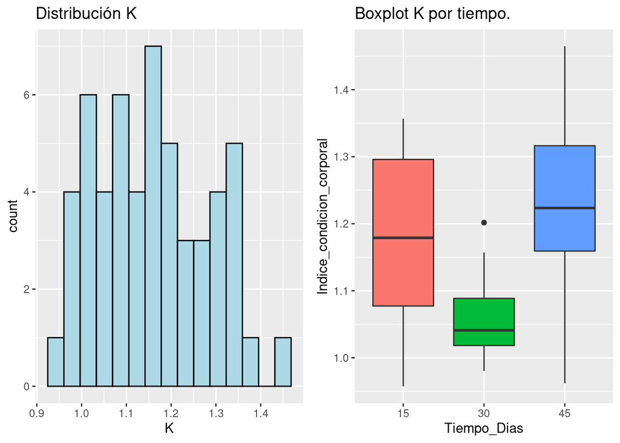

**d).** Calcule los estimadores puntuales de los promedios y las varianzas de la variable indice_condicion_corporal para cada nivel del factor Tiempo_Dias. Incluya también el N muestral. Use el paquete dplyr y los comandos **group_by()**, **summarise()**.

Estimadores puntuales de media, varianza de indice de condición por tiempo.

| Tiempo_Dias | N | Promedio | Varianza |
| --- | --- | --- | --- |
| 15 | 18 | 1.175539 | 0.0169992 |
| 30 | 18 | 1.061343 | 0.0035773 |
| 45 | 18 | 1.234744 | 0.0126285 |

**e).** Realice el ajuste del siguiente modelo usando la función lm,(), donde los parámetros son los siguientes: variable respuesta indice_condicion_corporal y como factor de clasificación Tiempo_Dias, como set de datos (data=Trucha). Llame al objeto model2_anova1. Utilice el simbolo ~ para relacionar la variable respuesta con el factor de clasificación. Realice el anova() del objeto model2_anova1.

```
## Analysis of Variance Table
##
## Response: indice_condicion_corporal
##             Df  Sum Sq  Mean Sq F value    Pr(>F)
## Tiempo_Dias  2 0.27968 0.139842  12.634 3.493e-05 ***
## Residuals   51 0.56449 0.011068
## ---
## Signif. codes:  0 '***' 0.001 '**' 0.01 '*' 0.05 '.' 0.1 ' ' 1
```

Use la función pander::pander() para mostrar los resultados del modelo (model2_anova1), coloque en el parámetro caption un título a la tabla.

ANOVA a un criterio de clasificación.

|  | Df | Sum Sq | Mean Sq | F value | Pr(>F) |
| --- | --- | --- | --- | --- | --- |
| **Tiempo_Dias** | 2 | 0.2797 | 0.1398 | 12.63 | 3.493e-05 |
| **Residuals** | 51 | 0.5645 | 0.01107 | NA | NA |

**f).** Hacer la prueba a posteriori de Tukey sobre el objeto model2_anova1. Para esto use la función TukeyHSD(). LLame el objeto Tuk_model2_anova1.

```
##   Tukey multiple comparisons of means
##     95% family-wise confidence level
##
## Fit: aov(formula = indice_condicion_corporal ~ Tiempo_Dias, data = Trucha)
##
## $Tiempo_Dias
##              diff         lwr         upr     p adj
## 30-15 -0.11419567 -0.19885084 -0.02954049 0.0056066
## 45-15  0.05920552 -0.02544965  0.14386069 0.2194788
## 45-30  0.17340119  0.08874601  0.25805636 0.0000255
```

**g).** Interprete los resultados.

```r
#El efecto Tiempo_Dias es estadísticamente significativo (p valor menor al nivel de significación del 5%). En consecuencia se rechaza la hipótesis nula. Por lo tanto, al menos existe un indice corporal promedio diferente en los días evaluados. Para estudiar a que son debidas esas diferencias se hizo una prueba de comparaciones a posteriori de Tukey y se obtuvo que las diferencias se presentaron entre los indices de condiciones corporales promedios de los días (30 y 15) y también entre (45 y 30).
```

### **Ejercicio 5.** **Anova a un criterio de clasificación y Prueba a Posteriori Tukey**

En este estudio de caso trabajaremos con un set de datos de arroz (*rice*) del paquete de R **agriTutorial** (n=135). rice {agriTutorial}

Las variables de estudio se describen a continuación: solo se consideraron algunas variables del set de datos para su descripción.

| **Variable** | **Descripción** | **Tipo de efecto/ variable** |
| --- | --- | --- |
| **Management** | Tres prácticas de manejo (minimum, optimum, intensive. | Criterio de clasificación/ Factor de tratamiento cualitativo. |
| **Nitrogen** | 5 cantidades de fertilizador de nitrógeno (0,50,80,110,140 kg/ha). | Variable regresora númerica/ Factor de tratamiento cuantitativo. |
| **Varieties** | 3 Variedades (V1, V2, V3). | Criterio de clasificación / Factor de tratamiento cualitativo. |
| **yield** | Rendimiento (g). | Variable respuesta/ Cuantitativa continua. |

**a).** Formule la hipótesis nula y alternativa para evaluar si el rendimiento (yield) promedio es igual para las tres prácticas de manejo.

```r
#**H~0~**: $$\mu_{Minimum} = \mu_{Optimum} = \mu_{Intensive}$$
#**H~1~**: Al menos una de las medias del rendimiento es diferente para cada práctica de manejo.
```

**b).** Importe el set de datos **data(rice)** del paquete **agriTutorial**. Explore el set de datos usando las funciones **head()**, **str()** y **summary()**.

```
##   yield nrate nitrogen Replicate management variety Main Sub
## 1 3.320     0        0        R1    Minimum      V1    1   1
## 2 6.101     0        0        R1    Minimum      V2    1   1
## 3 5.355     0        0        R1    Minimum      V3    1   1
## 4 3.766     0        0        R1    Optimum      V1    1   2
## 5 5.096     0        0        R1    Optimum      V2    1   2
## 6 7.442     0        0        R1    Optimum      V3    1   2
```

```
## 'data.frame':    135 obs. of  8 variables:
##  $ yield     : num  3.32 6.1 5.36 3.77 5.1 ...
##  $ nrate     : num  0 0 0 0 0 0 0 0 0 50 ...
##  $ nitrogen  : Factor w/ 5 levels "0","50","80",..: 1 1 1 1 1 1 1 1 1 2 ...
##  $ Replicate : Factor w/ 3 levels "R1","R2","R3": 1 1 1 1 1 1 1 1 1 1 ...
##  $ management: Factor w/ 3 levels "Minimum","Optimum",..: 1 1 1 2 2 2 3 3 3 1 ...
##  $ variety   : Factor w/ 3 levels "V1","V2","V3": 1 2 3 1 2 3 1 2 3 1 ...
##  $ Main      : Factor w/ 5 levels "1","2","3","4",..: 1 1 1 1 1 1 1 1 1 2 ...
##  $ Sub       : Factor w/ 3 levels "1","2","3": 1 1 1 2 2 2 3 3 3 1 ...
```

```
##      yield            nrate     nitrogen Replicate     management variety
##  Min.   : 3.132   Min.   :  0   0  :27   R1:45     Minimum  :45   V1:45
##  1st Qu.: 5.301   1st Qu.: 50   50 :27   R2:45     Optimum  :45   V2:45
##  Median : 6.509   Median : 80   80 :27   R3:45     Intensive:45   V3:45
##  Mean   : 6.554   Mean   : 76   110:27
##  3rd Qu.: 7.644   3rd Qu.:110   140:27
##  Max.   :10.360   Max.   :140
##  Main   Sub
##  1:27   1:45
##  2:27   2:45
##  3:27   3:45
##  4:27
##  5:27
##
```

**c).** Realice un análisis exploratorio de datos de la variable bajo estudio. A partir del set de datos de elabore un histograma de la variable respuesta **yield**. Además, realice un gráfico de cajas y bigotes para la variable **yield** y como criterio de clasificación **management**.

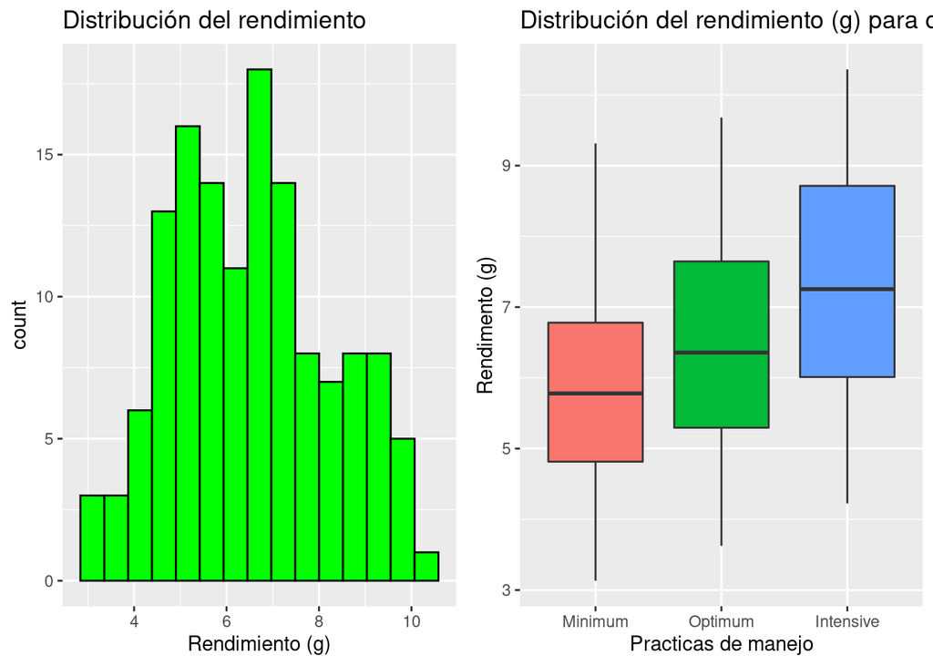

**d).** Halle los estimadores puntuales de los promedios y las varianzas de la variable yield para cada nivel del factor management. Incluya también el **N** muestral. Use el paquete dplyr y los comandos **group_by()**, **summarise()**.

Estimadores puntuales de media, varianza del rendimiento por práctica de manejo.

| management | N | Promedio | Varianza |
| --- | --- | --- | --- |
| Minimum | 45 | 5.900378 | 2.209773 |
| Optimum | 45 | 6.486156 | 2.630677 |
| Intensive | 45 | 7.276711 | 2.673291 |

**e).** Realice el ajuste del siguiente modelo usando la función aov(), donde los parámetros son los siguientes: variable respuesta **yield** y como factor de clasificación management, como set de datos (rice). Llame al objeto model3_anova1. Utlice el simbolo ~ para relacionar la variable respuesta con el factor de clasificación. Aplique la función anova() al modelo ajustado.

```
## Analysis of Variance Table
##
## Response: yield
##             Df Sum Sq Mean Sq F value    Pr(>F)
## management   2  42.94 21.4681  8.5715 0.0003163 ***
## Residuals  132 330.60  2.5046
## ---
## Signif. codes:  0 '***' 0.001 '**' 0.01 '*' 0.05 '.' 0.1 ' ' 1
```

Realice el anova() del objeto model3_anova1. Use la función pander::pander() para mostrar los resultados del modelo (model3_anova1), coloque en el parámetro caption un título a la tabla.

ANOVA a una vía de clasificación usando la función aov().

|  | Df | Sum Sq | Mean Sq | F value | Pr(>F) |
| --- | --- | --- | --- | --- | --- |
| **management** | 2 | 42.94 | 21.47 | 8.572 | 0.0003163 |
| **Residuals** | 132 | 330.6 | 2.505 | NA | NA |

**f).** Interprete los resultados.

```r
#El efecto práctica de manejo es estadísticamente significativo (p valor menor al nivel de significación del 5%). En consecuencia, hay evidencia para rechazar la hipótesis nula. Por lo tanto, existen diferencias entre los rendimientos promedio para las practicas de manejo. Por lo tanto, hay que hacer la prueba a posteriori de Tukey para identificar cuales diferencias entre prácticas de manejo son estadísticamente significativas.
```

**g).** Hacer la prueba a posteriori de Tukey sobre el objeto model3_anova1. Para esto use la función TukeyHSD(). LLame el objeto Tuk_model3_anova1.

```
##   Tukey multiple comparisons of means
##     95% family-wise confidence level
##
## Fit: aov(formula = yield ~ management, data = rice)
##
## $management
##                        diff           lwr      upr     p adj
## Optimum-Minimum   0.5857778 -0.2050943290 1.376650 0.1886744
## Intensive-Minimum 1.3763333  0.5854612265 2.167205 0.0001916
## Intensive-Optimum 0.7905556 -0.0003165513 1.581428 0.0501162
```

**h).** Interprete los resultados.

```r
#Se obtuvo que las diferencias entre las practicas de manejo Intensive y Minimum fueron estadísticamente significativas.
```

### **Ejercicio 6.** **Anova a dos criterios de clasificación con interacción**

Considerar la base de datos **rice** del ejercicio anterior.

**a).** Formule la hipótesis nula y alternativa para evaluar si el rendimiento promedio es el mismo para las diferentes prácticas de manejo y variedades e interacción entre práctica de manejo y variedad. Recuerde que cada efecto tiene una prueba de hipótesis asociada.

```r
# Hipótesis nula para el efecto práctica de manejo
#**H~0~**: $$\mu_{Minimum} = \mu_{Optimum} = \mu_{Intensive}$$
# Hipótesis nula para el efecto variedad
#**H~0~**: $$\mu_{V1} = \mu_{V2} = \mu_{V3}$$
# Hipótesis nula para el efecto de interacción entre práctica de manejo y variedad.
#**H~0~**: $$Management_i*Variety_j=0$$
# Hipotesis alternativa
#**H~1~**: Al menos una de las medias del rendimiento es diferente para cada práctica de manejo y variedad.
```

**b).** Realice un análisis exploratorio de datos de la variable bajo estudio. A partir del set de datos de elabore un gráfico de cajas y bigotes para la variable **yield**, como criterios de clasificación management y variety y particionado por variety use **facet_wrap(~ variety)**. Considere está capa en el gráfico para que no queden las etiquetas del eje x solapadas **theme(axis.text.x = element_text(angle = 45))**

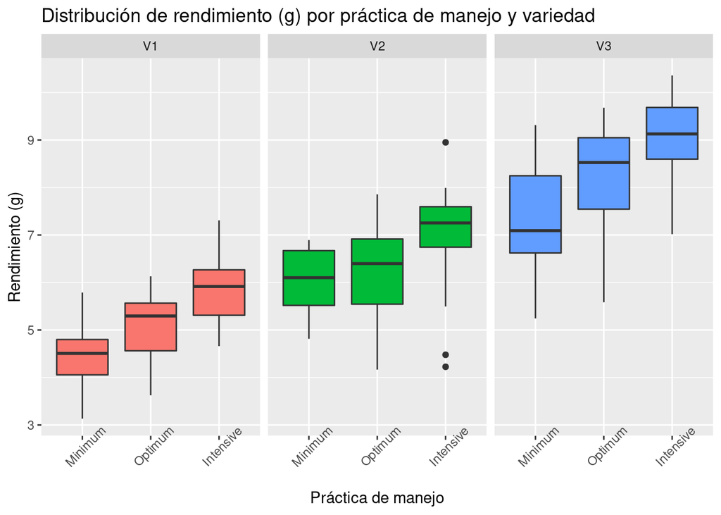

**c).** Halle los estimadores puntuales de los promedios y las varianzas de la variable yield para cada nivel del factor management y para cada nivel del factor variety. Incluya tambien el N muestral. Use el paquete dplyr y los comandos **group_by()**, **summarise()**.

Estimadores puntuales de media, varianza de rendimiento para cada práctica de manejo y variedad.

| management | variety | N | Promedio | Varianza |
| --- | --- | --- | --- | --- |
| Minimum | V1 | 15 | 4.413400 | 0.5977764 |
| Minimum | V2 | 15 | 6.055000 | 0.4574686 |
| Minimum | V3 | 15 | 7.232733 | 1.5931326 |
| Optimum | V1 | 15 | 5.054667 | 0.5777305 |
| Optimum | V2 | 15 | 6.223000 | 1.0332691 |
| Optimum | V3 | 15 | 8.180800 | 1.3101662 |
| Intensive | V1 | 15 | 5.912400 | 0.5788255 |
| Intensive | V2 | 15 | 6.910400 | 1.6388465 |
| Intensive | V3 | 15 | 9.007333 | 0.8370490 |

**d).** Realice el ajuste del siguiente modelo usando la función aov(), donde los parámetros son los siguientes: variable respuesta **yield** y como factores de clasificación management y variety, como set de datos (data= rice). Llame al objeto model4_anova1. Utilice el simbolo ~ para relacionar la variable respuesta con los factores de clasificación y su interacción. *Nota*: Considere management*variety; ya que está forma reducida en el modelo considera cada efecto principal y el efecto de interacción de forma simultánea. Aplique la función anova() al modelo ajustado.

```
## Analysis of Variance Table
##
## Response: yield
##                     Df  Sum Sq Mean Sq  F value    Pr(>F)
## management           2  42.936  21.468  22.4034 4.737e-09 ***
## variety              2 206.013 103.007 107.4943 < 2.2e-16 ***
## management:variety   4   3.852   0.963   1.0049    0.4076
## Residuals          126 120.740   0.958
## ---
## Signif. codes:  0 '***' 0.001 '**' 0.01 '*' 0.05 '.' 0.1 ' ' 1
```

Realice el anova() del objeto model4_anova1. Use la función pander::pander() para mostrar los resultados del modelo (model4_anova1), coloque en el parámetro caption un título a la tabla.

ANOVA a dos vías de clasificación con interacción usando la función aov().

|  | Df | Sum Sq | Mean Sq | F value | Pr(>F) |
| --- | --- | --- | --- | --- | --- |
| **management** | 2 | 42.94 | 21.47 | 22.4 | 4.737e-09 |
| **variety** | 2 | 206 | 103 | 107.5 | 5.764e-28 |
| **management:variety** | 4 | 3.852 | 0.9629 | 1.005 | 0.4076 |
| **Residuals** | 126 | 120.7 | 0.9583 | NA | NA |

**f).** Interprete los resultados.

```r
#Los efectos management y variety son estadísticamente significativos (p valor menor al nivel de significación del 5%). No obstante, el efecto de interacción management-variety no es estadísticamente significativo. Por lo tanto, no hay evidencia para rechazar la hipótesis nula para el término de interacción management*variety.
```